# Logistic Regression

Sumamry:

```
1. We started with the data exploration, performed missing data check and learned which features are important
2. We converted categorical features into numeric ones
3. Finally, we build a classifier to predict survival
4. We also evaluated the model performance using the classification report
```

```python
import pandas as pd
import numpy as np

import matplotlib
import matplotlib.pyplot as plt
from pandas.plotting import scatter_matrix
%matplotlib inline

import seaborn as sns
sns.set(style='white', color_codes=True)
sns.set(font_scale=1.5)

from sklearn.linear_model import LogisticRegression
from sklearn.model_selection import train_test_split

from sklearn.metrics import confusion_matrix
from sklearn.metrics import classification_report
from sklearn.metrics import accuracy_score
from sklearn.metrics import precision_score
from sklearn.metrics import recall_score
from sklearn.metrics import f1_score
from sklearn import metrics
```

To disable python warning, import warning

I started using this at the top of main.py:

```
    def warn(*args, **kwargs):
        pass
    import warnings
    warnings.warn = warn
```

# ... import sklearn stuff...

Another solution that worked for some:

```
    import warnings
    warnings.filterwarnings("ignore", category=DeprecationWarning)
```

```python
# import datasets
df_train = pd.read_csv('titanic_train.csv')
df_train.shape
```

```
(891, 12)
```

There are 891 rows and 12 columns

```python
# use head to determine the top 5 rows of the data
df_train.head()
```

|  | PassengerId | Survived | Pclass | Name | Sex | Age | SibSp | Parch | Ticket | Fare | Cabin | Embarked |
| --- | --- | --- | --- | --- | --- | --- | --- | --- | --- | --- | --- | --- |
| 0 | 1 | 0 | 3 | Braund, Mr. Owen Harris | male | 22.0 | 1 | 0 | A/5 21171 | 7.2500 | NaN | S |
| 1 | 2 | 1 | 1 | Cumings, Mrs. John Bradley (Florence Briggs Th... | female | 38.0 | 1 | 0 | PC 17599 | 71.2833 | C85 | C |
| 2 | 3 | 1 | 3 | Heikkinen, Miss. Laina | female | 26.0 | 0 | 0 | STON/O2. 3101282 | 7.9250 | NaN | S |
| 3 | 4 | 1 | 1 | Futrelle, Mrs. Jacques Heath (Lily May Peel) | female | 35.0 | 1 | 0 | 113803 | 53.1000 | C123 | S |
| 4 | 5 | 0 | 3 | Allen, Mr. William Henry | male | 35.0 | 0 | 0 | 373450 | 8.0500 | NaN | S |

```python
# let's get an idea of the columns using value_counts

df_train.Survived.value_counts()
```

```
0    549
1    342
Name: Survived, dtype: int64
```

There were 342 passengers who survived and 549 who did not survive

```python
# printing the sex of passengers
df_train.Sex.value_counts()
```

```
male      577
female    314
Name: Sex, dtype: int64
```

Printing the sex of passengers revealed that there were 577 males and 314 females

```python
df_train.Embarked.value_counts()
```

```
S    644
C    168
Q     77
Name: Embarked, dtype: int64
```

The Embarked values shows onboarding from each of the 3 ports that Titanic has docked.

- 644 passengers boarded from the city of South Hampton
- 168 from Chebourn and
- 77 from Queens Town

```python
# most occuring age of passengers
df_train.Age.mode()
```

```
0    24.0
dtype: float64
```

```python
# oldest age
df_train.Age.max()
```

```
80.0
```

```python
# age of youngest passenger
df_train.Age.min()
```

```
0.42
```

We need to check for null values as they reduce the quality of our performance metric.

```python
df_train.isnull().sum()
```

```
PassengerId      0
Survived         0
Pclass           0
Name             0
Sex              0
Age            177
SibSp            0
Parch            0
Ticket           0
Fare             0
Cabin          687
Embarked         2
dtype: int64
```

#### Let's see which of the columns are required for our analysis

Notice that Cabin has almost 80% missing values. **We will drop it completely.**

What about Age? Age seems like a relevant predictor for survival. We want to keep it but it has 177 missing values. We need to find a way to approximate those missing values and drop variables that aren't valuable for predicting survival.

We should at least keep the following variables:

- Survived
- Pclass: *Does the class influence survival rate*
- Sex
- Age: *Does age impact the survival rate?*
- SibSp: *Does the no of relatives on the boat that are siblings or spouse affect a persons survivability?*
- Parch: *Does the no. of relatives on the boat that are children or parents affect a persons survivability?*
- Fare: *Does the fare a person pay affect his survivability?*
- Embarked: *Does a person's point of embarking matter?* It depends on how the boat was filled; let's keep it.

A person's name, ticket number and passenger ID are irrelevant to predicting his survivability. As you recall, the Cabin variable is mostly missing values so let's drop all of these:

```python
df_train = df_train.drop(['PassengerId','Name', 'Ticket', 'Cabin'], axis=1)
df_train.head()
```

|  | Survived | Pclass | Sex | Age | SibSp | Parch | Fare | Embarked |
| --- | --- | --- | --- | --- | --- | --- | --- | --- |
| 0 | 0 | 3 | male | 22.0 | 1 | 0 | 7.2500 | S |
| 1 | 1 | 1 | female | 38.0 | 1 | 0 | 71.2833 | C |
| 2 | 1 | 3 | female | 26.0 | 0 | 0 | 7.9250 | S |
| 3 | 1 | 1 | female | 35.0 | 1 | 0 | 53.1000 | S |
| 4 | 0 | 3 | male | 35.0 | 0 | 0 | 8.0500 | S |

Let's use a histogram to vixualize the Age.

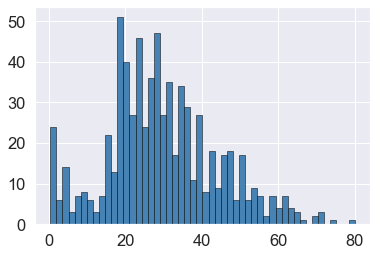

```python
df_train['Age'].hist(bins=50, color='steelblue', edgecolor='black', linewidth=0.5, grid=True)
```

Notice that Age is **right skewed and using the mean might give us biased results** by filling Ages that are over than desired. To deal with this, we'll use the **median** to impute the missing values.

Checking the average Age per class, we find

- the average age for first class is 38
- for the second class, it's around 30 and
- for third class, it's 25

From the above analysis, we could say that the younger a passenger is, the more likely it is for them to be in third class. The older a passenger is, the more likely it is for them to be in first class.

We need to deal with the missing values in the Age variable. Let's write a function to find each null value in the age variable:

```python
def age_approx(cols):
    Age = cols[0]
    Pclass = cols[1]

    if pd.isnull(Age):
        if Pclass == 1:
            return 37
        elif Pclass == 2:
            return 29
        else:
            return 24
    else:
        return Age
```

```python
df_train.groupby(['Pclass']).mean()
```

| Pclass | Survived | Age | SibSp | Parch | Fare |
| --- | --- | --- | --- | --- | --- |
| 1 | 0.629630 | 38.233441 | 0.416667 | 0.356481 | 84.154687 |
| 2 | 0.472826 | 29.877630 | 0.402174 | 0.380435 | 20.662183 |
| 3 | 0.242363 | 25.140620 | 0.615071 | 0.393075 | 13.675550 |

Replacing null values in the dataframe

```python
df_train['Age'] = df_train[['Age', 'Pclass']].apply(age_approx, axis=1)
```

Let's verify if any null values are present after the transformation above

```python
df_train.isnull().sum()
```

```
Survived    0
Pclass      0
Sex         0
Age         0
SibSp       0
Parch       0
Fare        0
Embarked    2
dtype: int64
```

There are 2 null variables in the embarked variable which we'll drop.

```python
df_train.dropna(inplace=True)
df_train.isnull().sum()
```

```
Survived    0
Pclass      0
Sex         0
Age         0
SibSp       0
Parch       0
Fare        0
Embarked    0
dtype: int64
```

Checking data types of columns will show that Sex and Embarked are of categorical data type so need to be converted to dummies using pd.get_dummies

```python
df_train_dummies = pd.get_dummies(df_train, columns=['Sex'])
df_train_dummies = pd.get_dummies(df_train_dummies, columns=['Embarked'])  # notice how the output of the 1st is the input for this
df_train_dummies.head()
```

|  | Survived | Pclass | Age | SibSp | Parch | Fare | Sex_female | Sex_male | Embarked_C | Embarked_Q | Embarked_S |
| --- | --- | --- | --- | --- | --- | --- | --- | --- | --- | --- | --- |
| 0 | 0 | 3 | 22.0 | 1 | 0 | 7.2500 | 0 | 1 | 0 | 0 | 1 |
| 1 | 1 | 1 | 38.0 | 1 | 0 | 71.2833 | 1 | 0 | 1 | 0 | 0 |
| 2 | 1 | 3 | 26.0 | 0 | 0 | 7.9250 | 1 | 0 | 0 | 0 | 1 |
| 3 | 1 | 1 | 35.0 | 1 | 0 | 53.1000 | 1 | 0 | 0 | 0 | 1 |
| 4 | 0 | 3 | 35.0 | 0 | 0 | 8.0500 | 0 | 1 | 0 | 0 | 1 |

We also need to find out if variables are **correlated**. Let's utilize the heatmap to do this:

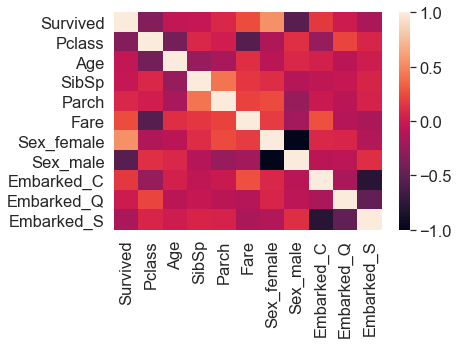

```python
plt.figure(figsize=(6,4))
sns.heatmap(df_train_dummies.corr())
```

Notice that there is a strong correlation between 'Survived' and 'Sex_Female' variables. Now let us build a classifier which predict survival.

#### Creating train and test datasets using X and y variables

```python
used_features = ['Pclass', 'Age', 'SibSp', 'Parch', 'Sex_female', 'Sex_male', 'Embarked_C', 'Embarked_Q', 'Embarked_S']

X = df_train_dummies[used_features].values
y = df_train_dummies['Survived']
```

```python
# splitting the data set as train and test
X_train, X_test, y_train, y_test = train_test_split(X, y, test_size=0.3, random_state=1)

# checking the shape of train and test datasets
print(X_train.shape)
print(X_test.shape)
print(y_train.shape)
print(y_test.shape)
```

```
(622, 9)
(267, 9)
(622,)
(267,)
```

#### Instantiate and train the classifier using the code:

```python
logreg = LogisticRegression()
```

```python
logreg.fit(X_train, y_train)
```

```
LogisticRegression()
```

```python
# storing the prediction given by the classifier in the y_pred variable
y_pred = logreg.predict(X_test)
```

```python
# compute the confusion matrix to evaluate the accuracy of the classification
metrics.confusion_matrix(y_test, y_pred)
```

```
array([[143,  23],
       [ 22,  79]], dtype=int64)
```

Let's interprete this result:

Out of the 166 actual instances of NOT SURVIVED, the classifier predicted correctly 143 of them.

Out of the 101 instanced of SURVIVED, the classifier predicted correctly 79 of them.

```python
metrics.accuracy_score(y_test, y_pred)
```

```
0.8314606741573034
```

Thus the algorithm has an accuracy of 83%. That is for every 100 passengers, 83 were correctly classified as survived or not survived.  
We can also compute other performance measures from the confusion matrix:

```python
print(classification_report(y_test, y_pred))
```

```
              precision    recall  f1-score   support

           0       0.87      0.86      0.86       166
           1       0.77      0.78      0.78       101

    accuracy                           0.83       267
   macro avg       0.82      0.82      0.82       267
weighted avg       0.83      0.83      0.83       267
```

The algorithm has good precision and recall scores.

The coefficient and intercept of the predicted line can be computed as below:

```python
logreg.coef_
```

```
array([[-1.0416583 , -0.03986563, -0.2418657 , -0.0405489 ,  1.19684229,
        -1.191862  ,  0.35142572, -0.03561634, -0.3108291 ]])
```

```python
logreg.intercept_
```

```
array([3.6503613])
```

```python
df_train_dummies[used_features].columns
```

```
Index(['Pclass', 'Age', 'SibSp', 'Parch', 'Sex_female', 'Sex_male',
       'Embarked_C', 'Embarked_Q', 'Embarked_S'],
      dtype='object')
```

We can further check our algorithm's predicted probability using the X_test values

```python
logreg.predict_proba(X_test)
```

[output not shown]

[output cut: 212 more lines]

```
       [0.39777162, 0.60222838],
       [0.94114063, 0.05885937],
       [0.1091533 , 0.8908467 ],
       [0.2255163 , 0.7744837 ],
       [0.88223956, 0.11776044],
       [0.90490942, 0.09509058],
       [0.0392098 , 0.9607902 ],
       [0.78105502, 0.21894498],
       [0.20154181, 0.79845819],
       [0.87412418, 0.12587582],
       [0.6573329 , 0.3426671 ],
       [0.87370032, 0.12629968],
       [0.29421217, 0.70578783],
       [0.84008588, 0.15991412],
       [0.91187725, 0.08812275]])
```

The first column is the probability that the entry has not the survived label and the second column is the probability that the entry has the survived label.